# GBI-OVN

December 4, 2015

## Motivation

## Why?

- We want to collaborate on researching and implementing our visions;
  - We want this collaboration to be free of constraints on which vision and how we should pursue individually;
  - Yet, our individual work should contribute to the overall vision and draw inspiration / ideas / knowledge from others;
- This does not go easy:
  - We have a number of projects (both internally and externally) which revolve around the same ideas yet are somewhat isolated:
    - Challenge propagation, chemical organization theory, offer networks, FutureICT, Computing in the Web, Holomidal Collective Intelligence, Ceptr, etc…

## What?

- Combine two kinds of thinking:
  - Conceptual guidance (philosophers, scientists, theoreticians, …);
  - Unconstrained experimentation (entrepreneurs, hackers, developers, …);

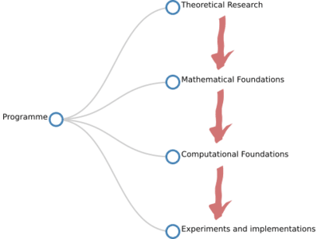

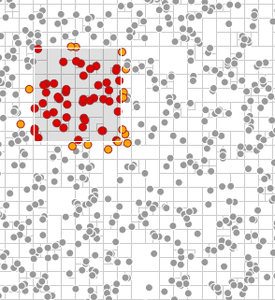

## Knowledge flows

- We want both conceptual guidance and unconstrained experimentation:

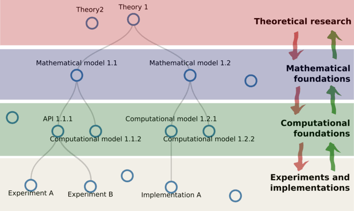

## Purpose

- Create more value via collaboration:
  - Connect the areas without constraining activities within them;
  - Attract people who are doing relevant research for sharing;
- Distribute the created value among participants;

## How?

GBI Open Value Network  
([GBI-OVN](https://ovn.globalbraininstitute.org))

Lean startup methodology  
([Lean startup](https://en.wikipedia.org/wiki/Lean_startup))

Open Value Networks paradigm  
([OVN Initiative](http://cargo.notthisbody.com/Open-Value-Networks))

## Lean startup methodology

## Define \(\rightarrow\) experiment \(\rightarrow\) learn loop

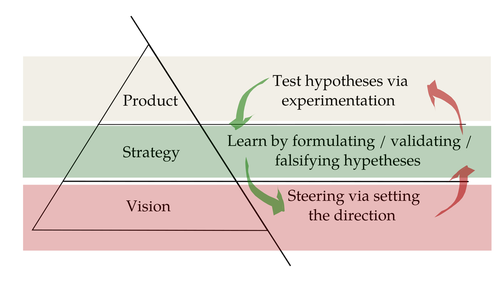

## Executing the loop

[figure not shown]

## A closer look

[figure not shown]

## Open Value Networks

## A framework for open collaboration

- Allows for:
  - Co-creation of value through large-scale collaboration;
  - Distribution of value where it is needed;
- Via:
  - 'Stigmergic' and 'directed' resource sharing (incl. knowledge) among diverse initiatives and sub-communities;
  - Self-organization of **"value synapses"** (as contrasted with definition of value chains);
  - Trust, implicit and explicit partnership agreements;
  - Governance paradigm for loosely defined initiatives;

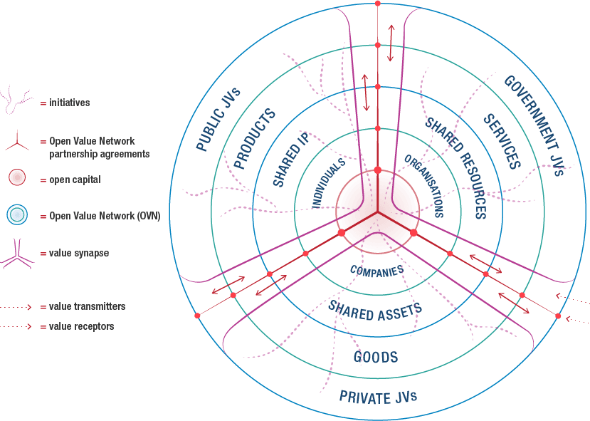

## Applicability

- Open Value Networks is a general framework;
- It reveals its power (and actually is created) via pilot projects, e.g.:
  - Sensorica.co http://www.sensorica.co/ - open hardware network;
  - Metamaps.cc http://metamaps.cc/ - real-time sense-making software;
  - …?
- There are no ready-made solutions, but many tools, approaches and guidelines which should be adapted to specific circumstances;

## GBI-OVN

## Structure of the network

[figure not shown]

## Medium of cooperation

https://ovn.globalbraininstitute.org

[figure not shown]

## Structure of the network (2)

[interactive chart not shown]

## Vision

- GBI-OVN:
  - is a value (scientific, monetary, otherwise) creation, sharing and distribution network based on the synergy of internal and external resources and people;
  - aims at facilitating and governing the large scale collaboration towards developing The Global Brain theory and technologies;
  - The network guides the self-organization of diverse expertise, knowledge, resources and financial sources (EU funds, commercial projects, philanthropy), people and ideas sharing the same broad vision.

## Further steps

- Acknowledge the shared understanding;
- Define the project's governance;
- Outline foreseeable scope of work required for the project;
- Build, collaborate, suggest, search, integrate, experiment…